# Modélisation de la classification des données de l'iris

Fallou Diagne Datascientist

23/02/2019

# 1 introduction

# 2 Connaître les données

## 2.1 Charger le paquet

```r
library(tidyverse) # visualization/processing
library(lattice)# visualization
library(ggpubr) # for multiple plots
library(GGally) # for pairplots
library(caret)  # machine learning models
library(skimr)
```

## 2.2 Importer les données

```r
dataset <- read.csv("iris.csv")
```

Renommer les variables

```r
data=dataset
dataset=dataset %>% rename(
  SepalLengthCm=Sepal.Length,
  SepalWidthCm=Sepal.Width,
  PetalLengthCm=Petal.Length,
  PetalWidthCm=Petal.Width
)
```

## 2.3 Vérifier les données en utilisant différentes méthodes

Nous commençons par nous faire une idée des dimensions, de la taille et des attributs des données sur lesquelles nous travaillons.

```r
head(dataset,3)#top 3 rows
```

```
##   SepalLengthCm SepalWidthCm PetalLengthCm PetalWidthCm Species
## 1           5.1          3.5           1.4          0.2  setosa
## 2           4.9          3.0           1.4          0.2  setosa
## 3           4.7          3.2           1.3          0.2  setosa
```

```r
tail(dataset,3)#bottom 3 rows
```

```
##     SepalLengthCm SepalWidthCm PetalLengthCm PetalWidthCm   Species
## 148           6.5          3.0           5.2          2.0 virginica
## 149           6.2          3.4           5.4          2.3 virginica
## 150           5.9          3.0           5.1          1.8 virginica
```

```r
dim(dataset)#shape
```

```
## [1] 150   5
```

```r
names(dataset)#variables
```

```
## [1] "SepalLengthCm" "SepalWidthCm"  "PetalLengthCm" "PetalWidthCm"
## [5] "Species"
```

```r
str(dataset)#structures
```

```
## 'data.frame':    150 obs. of  5 variables:
##  $ SepalLengthCm: num  5.1 4.9 4.7 4.6 5 5.4 4.6 5 4.4 4.9 ...
##  $ SepalWidthCm : num  3.5 3 3.2 3.1 3.6 3.9 3.4 3.4 2.9 3.1 ...
##  $ PetalLengthCm: num  1.4 1.4 1.3 1.5 1.4 1.7 1.4 1.5 1.4 1.5 ...
##  $ PetalWidthCm : num  0.2 0.2 0.2 0.2 0.2 0.4 0.3 0.2 0.2 0.1 ...
##  $ Species      : Factor w/ 3 levels "setosa","versicolor",..: 1 1 1 1 1 1 1 1 1 1 ...
```

```r
lapply(dataset, function(x) length(unique(x))) # Unique values per column
```

```
## $SepalLengthCm
## [1] 35
##
## $SepalWidthCm
## [1] 23
##
## $PetalLengthCm
## [1] 43
##
## $PetalWidthCm
## [1] 22
##
## $Species
## [1] 3
```

Nous avons donc commencé à en savoir plus sur les données. L'ensemble de données comprend 50 échantillons de chacune des trois espèces d'Iris (Iris setosa, Iris virginica et Iris versicolor). Quatre caractéristiques ont été mesurées à partir de chaque échantillon: la longueur et la largeur des sépales et des pétales, en centimètres. Sur la base de la combinaison de ces quatre caractéristiques, nous devons développer quelques modèles pour distinguer les espèces les unes des autres.

```r
summary(dataset)#summary of the data
```

```
##  SepalLengthCm    SepalWidthCm   PetalLengthCm    PetalWidthCm
##  Min.   :4.300   Min.   :2.000   Min.   :1.000   Min.   :0.100
##  1st Qu.:5.100   1st Qu.:2.800   1st Qu.:1.600   1st Qu.:0.300
##  Median :5.800   Median :3.000   Median :4.350   Median :1.300
##  Mean   :5.843   Mean   :3.057   Mean   :3.758   Mean   :1.199
##  3rd Qu.:6.400   3rd Qu.:3.300   3rd Qu.:5.100   3rd Qu.:1.800
##  Max.   :7.900   Max.   :4.400   Max.   :6.900   Max.   :2.500
##        Species
##  setosa    :50
##  versicolor:50
##  virginica :50
##
##
##
```

Observation: Checking the scales of features is very important. Sepal length ranges from 4.3-7.9, Sepal width range: 2-4.4, Petal length range:1-6.9, Petal width:0.1-2.5. The ranges bascially are from 0 to 10, so we don’t have to do scaling before the building the models.

# 3 Clean the data

## 3.1 Any missing values?

```r
sum(is.na(dataset))#check overall
```

```
## [1] 0
```

```r
dataset %>%
  summarize_all(funs(sum(is.na(.))/n())) #check each column
```

```
##   SepalLengthCm SepalWidthCm PetalLengthCm PetalWidthCm Species
## 1             0            0             0            0       0
```

No missing values… very good…

```r
data<- dataset[,-1]
head(data)#check if Id removed or not
```

```
##   SepalWidthCm PetalLengthCm PetalWidthCm Species
## 1          3.5           1.4          0.2  setosa
## 2          3.0           1.4          0.2  setosa
## 3          3.2           1.3          0.2  setosa
## 4          3.1           1.5          0.2  setosa
## 5          3.6           1.4          0.2  setosa
## 6          3.9           1.7          0.4  setosa
```

## 3.3 Remove duplicate info in Species variable

```r
data$Species <- sapply(strsplit(as.character(data$Species),'-'), "[", 2)
str(data) #check the data again and found Species became character
```

```
## 'data.frame':    150 obs. of  4 variables:
##  $ SepalWidthCm : num  3.5 3 3.2 3.1 3.6 3.9 3.4 3.4 2.9 3.1 ...
##  $ PetalLengthCm: num  1.4 1.4 1.3 1.5 1.4 1.7 1.4 1.5 1.4 1.5 ...
##  $ PetalWidthCm : num  0.2 0.2 0.2 0.2 0.2 0.4 0.3 0.2 0.2 0.1 ...
##  $ Species      : chr  NA NA NA NA ...
```

```r
data$Species <- as.factor(data$Species)#change Species as factor
str(data)#check again, Species is factor variable now
```

```
## 'data.frame':    150 obs. of  4 variables:
##  $ SepalWidthCm : num  3.5 3 3.2 3.1 3.6 3.9 3.4 3.4 2.9 3.1 ...
##  $ PetalLengthCm: num  1.4 1.4 1.3 1.5 1.4 1.7 1.4 1.5 1.4 1.5 ...
##  $ PetalWidthCm : num  0.2 0.2 0.2 0.2 0.2 0.4 0.3 0.2 0.2 0.1 ...
##  $ Species      : Factor w/ 0 levels: NA NA NA NA NA NA NA NA NA NA ...
```

# 4 Visualization

## 4.1 Why plots?

To further dig the data, we need to check basic statistics indexes of the data including mean/standard deviation/count/max/min value for each numeric variables

```r
describle_datatable <- data %>%
  group_by(Species) %>%
  summarise_if(is.numeric,funs(mean, sd,n(), max, min))

t(describle_datatable) #transpose for easy checking
```

```
##                    [,1]
## Species            NA
## SepalWidthCm_mean  "3.057333"
## PetalLengthCm_mean "3.758"
## PetalWidthCm_mean  "1.199333"
## SepalWidthCm_sd    "0.4358663"
## PetalLengthCm_sd   "1.765298"
## PetalWidthCm_sd    "0.7622377"
## SepalWidthCm_n     "150"
## PetalLengthCm_n    "150"
## PetalWidthCm_n     "150"
## SepalWidthCm_max   "4.4"
## PetalLengthCm_max  "6.9"
## PetalWidthCm_max   "2.5"
## SepalWidthCm_min   "2"
## PetalLengthCm_min  "1"
## PetalWidthCm_min   "0.1"
```

Not easy to get more insights? so plots…

```r
skim(iris)
```

```
## Skim summary statistics
##  n obs: 150
##  n variables: 5
##
## ── Variable type:factor ───────────────────────────
##  variable missing complete   n n_unique                       top_counts
##   Species       0      150 150        3 set: 50, ver: 50, vir: 50, NA: 0
##  ordered
##    FALSE
##
## ── Variable type:numeric ──────────────────────────
##      variable missing complete   n mean   sd  p0 p25  p50 p75 p100
##  Petal.Length       0      150 150 3.76 1.77 1   1.6 4.35 5.1  6.9
##   Petal.Width       0      150 150 1.2  0.76 0.1 0.3 1.3  1.8  2.5
##  Sepal.Length       0      150 150 5.84 0.83 4.3 5.1 5.8  6.4  7.9
##   Sepal.Width       0      150 150 3.06 0.44 2   2.8 3    3.3  4.4
##      hist
##  ▇▁▁▂▅▅▃▁
##  ▇▁▁▅▃▃▂▂
##  ▂▇▅▇▆▅▂▂
##  ▁▂▅▇▃▂▁▁
```

## 4.2 boxplot

We begin by using boxplots to understand the distribution of attributes for each Species.

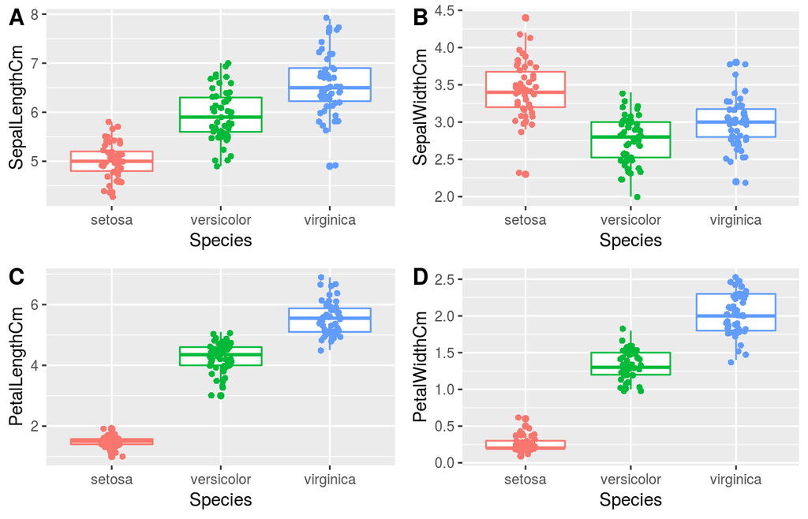

```r
data=dataset
p1 <- ggplot(data, aes(x = Species, y = SepalLengthCm,colour=Species)) +
  geom_boxplot() +
  geom_jitter(shape=16, position=position_jitter(0.1))+
  theme(legend.position="none") # Remove legend

p2 <- ggplot(data, aes(x = Species, y = SepalWidthCm,colour=Species)) +
  geom_boxplot() +
  geom_jitter(shape=16, position=position_jitter(0.1))+
  theme(legend.position="none") # Remove legend


p3 <- ggplot(data, aes(x = Species, y = PetalLengthCm,colour=Species)) +
  geom_boxplot() +
  geom_jitter(shape=16, position=position_jitter(0.1))+
  theme(legend.position="none") # Remove legend


p4 <- ggplot(data, aes(x = Species, y = PetalWidthCm,colour=Species)) +
  geom_boxplot() +
  geom_jitter(shape=16, position=position_jitter(0.1))+
  theme(legend.position="none") # Remove legend

ggpubr::ggarrange(p1,p2,p3,p4,
          labels = c("A", "B", "C","D"),
          ncol = 2, nrow = 2)
```

## 4.3 pairplot

To understand relationships between atrributes, let’s do the pairplots (package: GGally)

```r
head(data)
```

```
##   SepalLengthCm SepalWidthCm PetalLengthCm PetalWidthCm Species
## 1           5.1          3.5           1.4          0.2  setosa
## 2           4.9          3.0           1.4          0.2  setosa
## 3           4.7          3.2           1.3          0.2  setosa
## 4           4.6          3.1           1.5          0.2  setosa
## 5           5.0          3.6           1.4          0.2  setosa
## 6           5.4          3.9           1.7          0.4  setosa
```

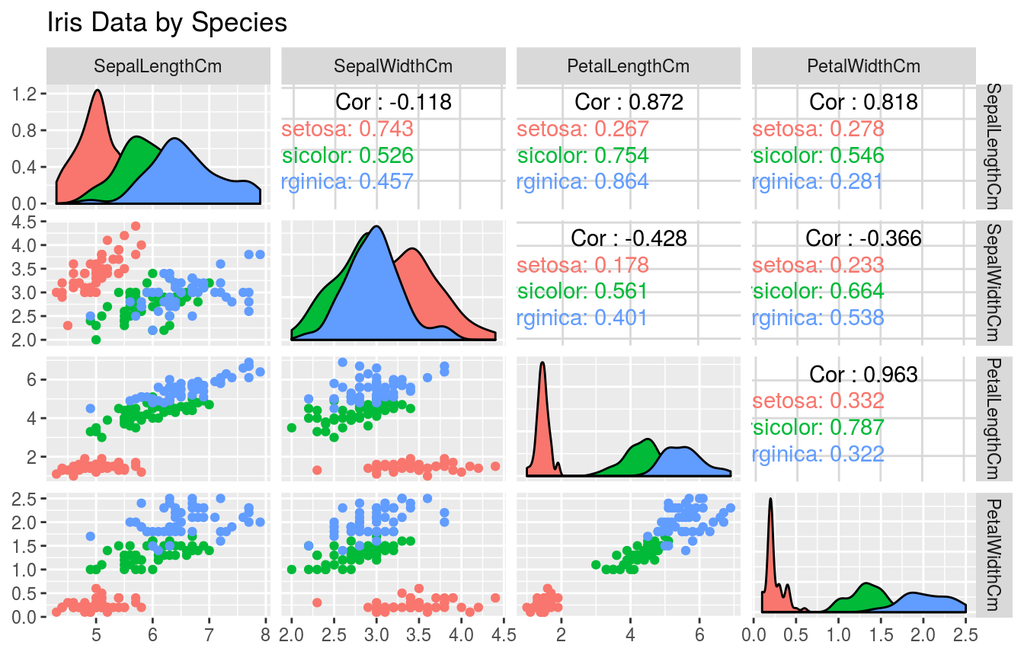

```r
ggpairs(data, columns=1:4, aes(color=Species)) +
  ggtitle("Iris Data by Species")
```

Petal width and Petal length have a strong linear correlation relationship.

## 4.4 scatterplot

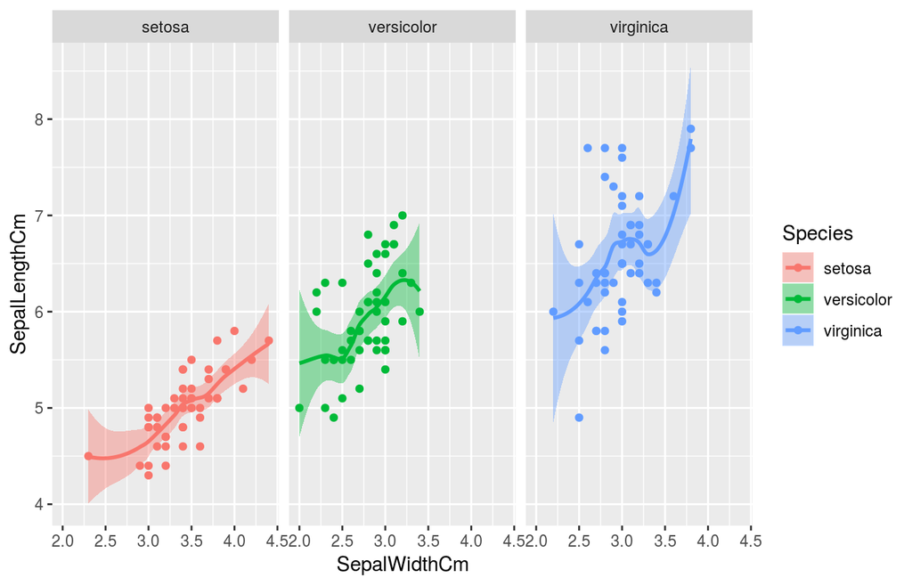

```r
ggplot(data, aes(x =SepalWidthCm , y = SepalLengthCm  , color = Species))+
  geom_point()+
  geom_smooth(method="loess", aes(fill= Species, color = Species))+
  facet_wrap(~Species, ncol = 3, nrow = 1)
```

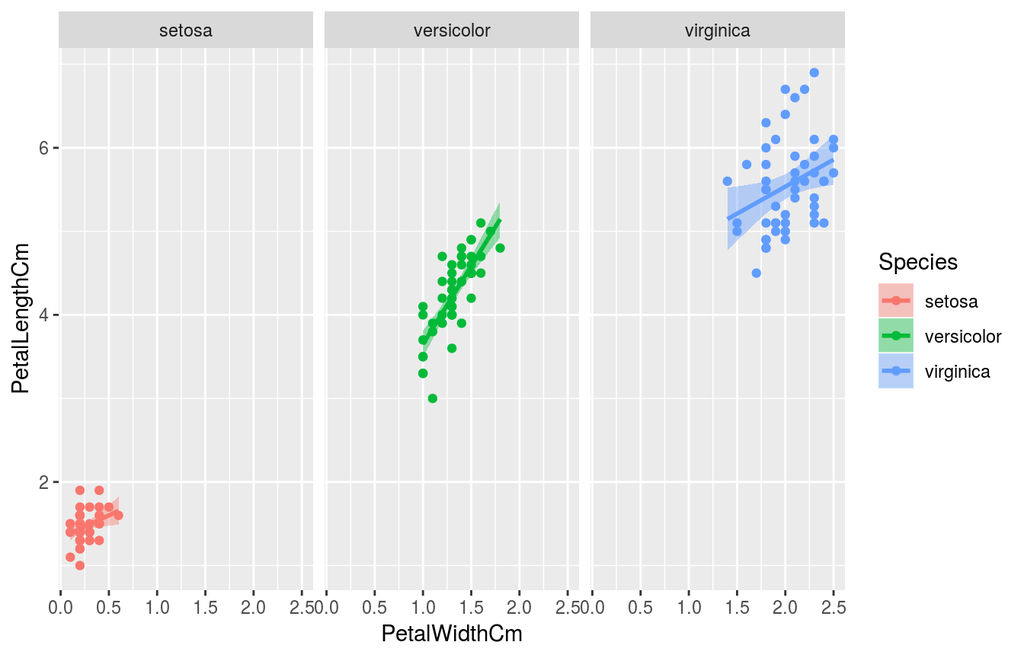

```r
ggplot(data, aes(x = PetalWidthCm , y =PetalLengthCm  , color = Species))+
  geom_point()+
  geom_smooth(method="lm", aes(fill= Species, color = Species))+
  facet_wrap(~Species, ncol = 3, nrow = 1)
```

Versicolor’s petal widith and length has a strong linear relationgship. Could we guess: petal width and petal length might be the key features for classfication? Just guess.. we need to do the predication.

# 5 Splitting the data for training and testing

```r
set.seed(101)
# We use the dataset to create a partition (80% training 20% testing)
id <- createDataPartition(data$Species, p=0.80, list=FALSE)

# select 80% of data to train the models
train <- data[id,]
dim(train)
```

```
## [1] 120   5
```

```r
# select 20% of the data for testing
test <- data[-id,]
dim(test)
```

```
## [1] 30  5
```

```r
#review the train dataset to confirm the Species are randomly selected
lapply(train, function(x) length(unique(x)))
```

```
## $SepalLengthCm
## [1] 34
##
## $SepalWidthCm
## [1] 21
##
## $PetalLengthCm
## [1] 42
##
## $PetalWidthCm
## [1] 21
##
## $Species
## [1] 3
```

```r
table(train$Species)
```

```
##
##     setosa versicolor  virginica
##         40         40         40
```

```r
summary(train)
```

```
##  SepalLengthCm    SepalWidthCm   PetalLengthCm    PetalWidthCm
##  Min.   :4.300   Min.   :2.000   Min.   :1.000   Min.   :0.100
##  1st Qu.:5.100   1st Qu.:2.800   1st Qu.:1.600   1st Qu.:0.300
##  Median :5.800   Median :3.000   Median :4.400   Median :1.300
##  Mean   :5.858   Mean   :3.055   Mean   :3.774   Mean   :1.198
##  3rd Qu.:6.425   3rd Qu.:3.400   3rd Qu.:5.100   3rd Qu.:1.800
##  Max.   :7.900   Max.   :4.200   Max.   :6.900   Max.   :2.500
##        Species
##  setosa    :40
##  versicolor:40
##  virginica :40
##
##
##
```

```r
str(train)
```

```
## 'data.frame':    120 obs. of  5 variables:
##  $ SepalLengthCm: num  5.1 4.9 4.7 4.6 5.4 4.6 5 4.4 5.4 4.8 ...
##  $ SepalWidthCm : num  3.5 3 3.2 3.1 3.9 3.4 3.4 2.9 3.7 3.4 ...
##  $ PetalLengthCm: num  1.4 1.4 1.3 1.5 1.7 1.4 1.5 1.4 1.5 1.6 ...
##  $ PetalWidthCm : num  0.2 0.2 0.2 0.2 0.4 0.3 0.2 0.2 0.2 0.2 ...
##  $ Species      : Factor w/ 3 levels "setosa","versicolor",..: 1 1 1 1 1 1 1 1 1 1 ...
```

Observation- 1.The train dataset has 120 observations while test dataset has 30. 2.Each class has the same number of instances (40).

# 6 Model building

## 6.1 Model 1: Cart Model: Decision tree

```r
set.seed(101)

cart_model <- train(train[,1:4], train[, 5], method='rpart2')
```

```
## note: only 2 possible values of the max tree depth from the initial fit.
##  Truncating the grid to 2 .
```

```r
# Predict the labels of the test set
predictions<-predict(cart_model,test[,1:4])

# Evaluate the predictions
table(predictions)
```

```
## predictions
##     setosa versicolor  virginica
##         10         11          9
```

```r
# Confusion matrix
confusionMatrix(predictions,test[,5])
```

```
## Confusion Matrix and Statistics
##
##             Reference
## Prediction   setosa versicolor virginica
##   setosa         10          0         0
##   versicolor      0         10         1
##   virginica       0          0         9
##
## Overall Statistics
##
##                Accuracy : 0.9667
##                  95% CI : (0.8278, 0.9992)
##     No Information Rate : 0.3333
##     P-Value [Acc > NIR] : 2.963e-13
##
##                   Kappa : 0.95
##  Mcnemar's Test P-Value : NA
##
## Statistics by Class:
##
##                      Class: setosa Class: versicolor Class: virginica
## Sensitivity                 1.0000            1.0000           0.9000
## Specificity                 1.0000            0.9500           1.0000
## Pos Pred Value              1.0000            0.9091           1.0000
## Neg Pred Value              1.0000            1.0000           0.9524
## Prevalence                  0.3333            0.3333           0.3333
## Detection Rate              0.3333            0.3333           0.3000
## Detection Prevalence        0.3333            0.3667           0.3000
## Balanced Accuracy           1.0000            0.9750           0.9500
```

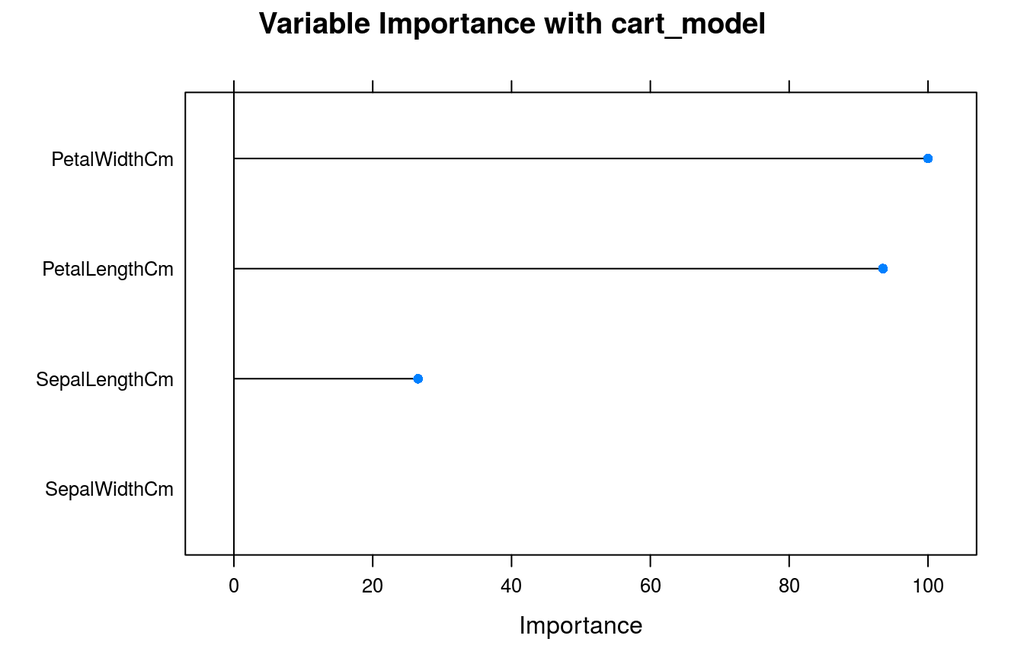

```r
#feature importance
importance_cart <- varImp(cart_model)
plot(importance_cart, main="Variable Importance with cart_model")
```

As suspected, Petal Width is the most used variable, followed by Petal Length and Sepal Length.

## 6.2 Model 2 KNN

```r
# Train the model with preprocessing
set.seed(101)

knn_model <- train(train[, 1:4], train[, 5], method='knn',
                   preProcess=c("center", "scale"))

# Predict values
predictions<-predict(knn_model,test[,1:4], type="raw")

# Confusion matrix
confusionMatrix(predictions,test[,5])
```

```
## Confusion Matrix and Statistics
##
##             Reference
## Prediction   setosa versicolor virginica
##   setosa         10          0         0
##   versicolor      0          9         2
##   virginica       0          1         8
##
## Overall Statistics
##
##                Accuracy : 0.9
##                  95% CI : (0.7347, 0.9789)
##     No Information Rate : 0.3333
##     P-Value [Acc > NIR] : 1.665e-10
##
##                   Kappa : 0.85
##  Mcnemar's Test P-Value : NA
##
## Statistics by Class:
##
##                      Class: setosa Class: versicolor Class: virginica
## Sensitivity                 1.0000            0.9000           0.8000
## Specificity                 1.0000            0.9000           0.9500
## Pos Pred Value              1.0000            0.8182           0.8889
## Neg Pred Value              1.0000            0.9474           0.9048
## Prevalence                  0.3333            0.3333           0.3333
## Detection Rate              0.3333            0.3000           0.2667
## Detection Prevalence        0.3333            0.3667           0.3000
## Balanced Accuracy           1.0000            0.9000           0.8750
```

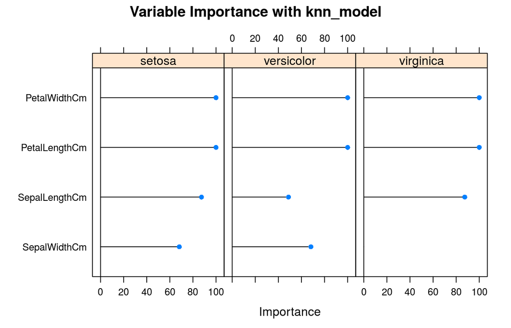

```r
#feature importance
importance_knn <- varImp(knn_model)
plot(importance_knn, main="Variable Importance with knn_model")
```

## 6.3 Model 3 Neural Network

```r
# Train the model with preprocessing
set.seed(101)
nnet_model <- train(train[, 1:4], train[, 5], method='nnet',
                   preProcess=c("center", "scale"),
                   tuneLength = 2,
                   trace = FALSE,
                   maxit = 100)

# Predict values
predictions<-predict(nnet_model,test[,1:4], type="raw")

# Confusion matrix
confusionMatrix(predictions,test[,5])
```

```
## Confusion Matrix and Statistics
##
##             Reference
## Prediction   setosa versicolor virginica
##   setosa         10          0         0
##   versicolor      0         10         0
##   virginica       0          0        10
##
## Overall Statistics
##
##                Accuracy : 1
##                  95% CI : (0.8843, 1)
##     No Information Rate : 0.3333
##     P-Value [Acc > NIR] : 4.857e-15
##
##                   Kappa : 1
##  Mcnemar's Test P-Value : NA
##
## Statistics by Class:
##
##                      Class: setosa Class: versicolor Class: virginica
## Sensitivity                 1.0000            1.0000           1.0000
## Specificity                 1.0000            1.0000           1.0000
## Pos Pred Value              1.0000            1.0000           1.0000
## Neg Pred Value              1.0000            1.0000           1.0000
## Prevalence                  0.3333            0.3333           0.3333
## Detection Rate              0.3333            0.3333           0.3333
## Detection Prevalence        0.3333            0.3333           0.3333
## Balanced Accuracy           1.0000            1.0000           1.0000
```

```r
#feature importance
importance_nnet <- varImp(nnet_model);importance_nnet
```

```
## nnet variable importance
##
##   variables are sorted by maximum importance across the classes
##               Overall setosa versicolor virginica
## PetalLengthCm  100.00 100.00     100.00    100.00
## PetalWidthCm    93.05  93.05      93.05     93.05
## SepalWidthCm    39.56  39.56      39.56     39.56
## SepalLengthCm    0.00   0.00       0.00      0.00
```